# Experience vs. description based decision-making project: Behavioral manipulation checks

# Set up environment and load in data

```r
library(tidyverse)
```

```r
library(gridExtra)
```

```r
helpers_path = '~/Documents/RangelLab/DescribedVsLearned/helpers/'
```

Read in clean data with Q-learning parameter estimates

```r
source(paste0(helpers_path,'fit_qlearning.R'))
```

# Manipulation checks

## Correct interpretation of p(Fractal)$

- When p of fractal is 0 do subjects choose based on the EV difference between lotteries? Does the QV difference matter at all?
- When p of fractal is 1 do subjects choose based on the QV difference between fractals? Does the EV difference matter at all?

```r
clean_beh_data %>%
  filter(probFractalDraw == 1 | probFractalDraw == 0) %>%
  mutate(leftQVAdv = leftQValue - rightQValue,
         leftLotteryEV = lotteryValue*lotteryProb,
         rightLotteryEV = referenceValue*referenceProb,
         leftEVAdv = leftLotteryEV - rightLotteryEV) %>%
  select(leftQVAdv, leftEVAdv, choiceLeft, probFractalDraw) %>%
  gather(key, value, -choiceLeft, -probFractalDraw) %>%
  mutate(key = ifelse(key == "leftEVAdv", "EV_left - EV_right", "QV_left - QV_right"),
         probFractalDraw = ifelse(probFractalDraw == 0, "p(Fractal)=0", "p(Fractal)=1"))%>%
  ggplot(aes(value, choiceLeft))+
  geom_jitter(width=0.03, height=0.08, alpha = 0.05)+
  geom_smooth(formula = 'y~x', method = "glm", method.args = list(family=binomial), fullrange=TRUE)+
  facet_grid(probFractalDraw~key)+
  xlab("")+
  ylab("p(Left)")
```

[output not shown]

**ADD Bayesian multilevel model and check the significance of slopes**

## Lottery bias in conflict trials

When the better lottery and the better fractal (based on the learned Q value) suggest different options do subjects choose more frequently based on the lottery or their fractal Q Value? Yes, there is a general tendency towards choosing the option with the better lottery even when the trial reward depends less on the lottery and more on the fractal (p(Fractal) >=.5). Only when the outcome depend entirely on the fractal are people more likely to choose the option with the better fractal but even then there is a non-negligible portion of choices determined by the lottery EV.

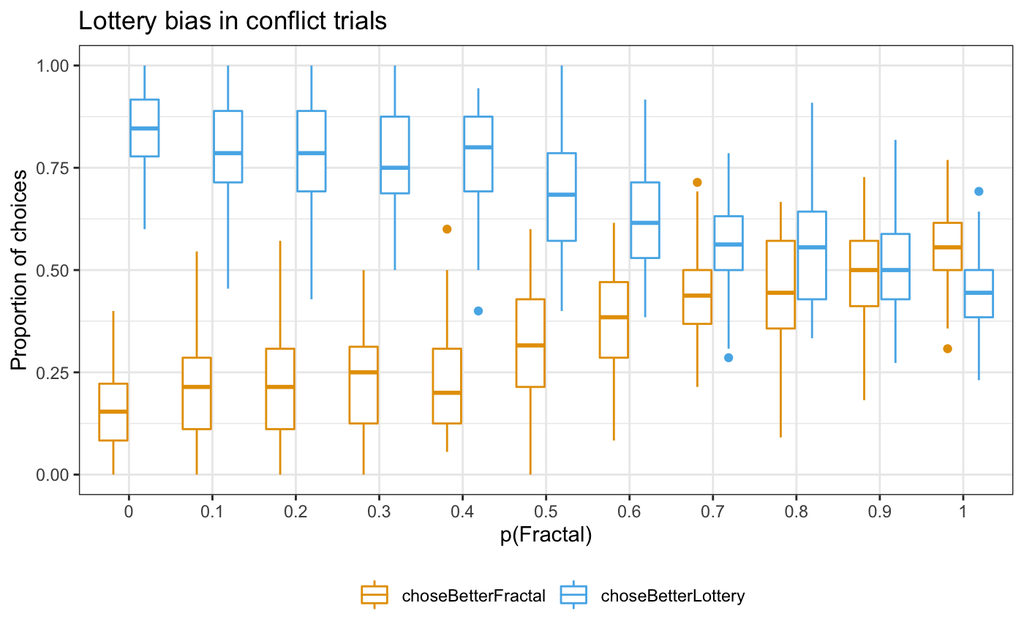

```r
clean_beh_data %>%
  mutate(leftLotteryEV = lotteryValue*lotteryProb,
         rightLotteryEV = referenceValue*referenceProb,
         leftLotteryBetter = leftLotteryEV>rightLotteryEV,
         choseBetterLottery = ifelse(leftLotteryBetter & choiceLeft == 1, 1,
                                     ifelse(!leftLotteryBetter & choiceLeft == 0, 1, 0)),
         leftFractalBetter = leftQValue>rightQValue,
         choseBetterFractal = ifelse(leftFractalBetter & choiceLeft == 1, 1,
                                     ifelse(!leftFractalBetter & choiceLeft == 0, 1, 0))) %>%
  filter(leftFractalBetter != leftLotteryBetter) %>%
  group_by(probFractalDraw, subnum) %>%
  summarise(choseBetterLottery = mean(choseBetterLottery),
            choseBetterFractal = mean(choseBetterFractal),
            .groups='keep') %>%
  gather(key, value, -probFractalDraw, -subnum) %>%
  ggplot(aes(as.factor(probFractalDraw), value, color=key))+
  geom_boxplot()+
 labs(x="p(Fractal)",y="Proportion of choices",color="", title="Lottery bias in conflict trials")
```

**ADD statistical test to check if the proportion of lottery based choices are higher than 50% for all levels of $\pi$**

- Do they not learn the fractal values well?
- Do they distort the probability of fractal and think it is less likely to get a reward from a fractal?